# Khem Veasna’s (kveasna@gmail.com) Report for Identify Fraud from Enron Email

## Overview

The goal of this project is to identify POIs (or persons of interest) from the public Enron data set. A POI is a person who may have committed fraud. The identification will be done using various machine learning algorithms.

## Basic Interrogation of the Data

There’s a total of 146 data points.

Number of data points that’s POI is 18 and number that’s not POI is 111 after running the data through the featureFormat function.

We summarize these features below:

```r
mean     6.417433e+06
std      3.794112e+07
min     -4.409300e+04
25%      3.849300e+05
50%      1.034346e+06
75%      2.502063e+06
max      4.345095e+08
```

```r
count         133.000000
mean      1463813.819549
std       8471902.937743
min             0.000000
25%             0.000000
50%        350000.000000
75%        850000.000000
max      97343619.000000
```

```r
count    133.000000
mean      26.661654
std       82.705748
min        0.000000
25%        0.000000
50%        0.000000
75%       15.000000
max      609.000000
```

Here bonus reveals what may be a clear outlier as the max value. It’s even clearer in a plot below.

## Outliers

We first check for outliers from the data. What may cause these outliers? User input error?

A clear outlier is caused by a data point with the key “TOTAL” as seen in the following plot. So it will be removed.

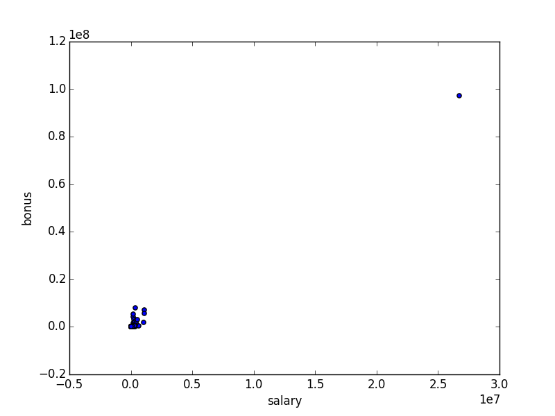

## Feature Selection

The features I selected are: [‘poi’,‘salary’, ‘bonus’,‘restricted_stock_deferred’, ‘total_stock_value’]

We also add two new features which are (a) the ratio of email sent to POI from a POI (from_this_person_to_poi/to_messages) (b) and email received from POI to POI (from_poi_to_this_person/from_messages).

The rationale behind the new features are borrowed from the course. Intuition would suggest that a POI would email another POI.

### Scaling

Scaling was done to the data because I wanted to use an SVM initially. Without feature scaling, the SVM would not work well. I actually ended up choosing a DecisionTree where feature scaling is not required.

## Algorithm Selection and Validation

I ended up selecting a DecisionTree.

```r
#tree.DecisionTreeClassifier(min_samples_split=3)

DecisionTreeClassifier(class_weight=None, criterion='gini', max_depth=None,
            max_features=None, max_leaf_nodes=None, min_samples_leaf=1,
            min_samples_split=3, min_weight_fraction_leaf=0.0,
            random_state=None, splitter='best')
    Accuracy: 0.78615   Precision: 0.30519  Recall: 0.30550 F1: 0.30535 F2: 0.30544
    Total predictions: 13000    True positives:  611    False positives: 1391   False negatives: 1389   True negatives: 9609
```

I tuned the algorithm to use min_samples_split=3 from experimentation. At a value of 10 and 5, the recall and precision scores were not >= .3.

A great “F1” score means that both the false positives and false negatives rate are low, so we can identify POIs reliably and accurately. Here with F1 score at 0.30535, we can’t reliably and accurately identify POIs.

### Other Algorithms

I tried an SVM with the following results:

```r
GridSearchCV(cv=None, error_score='raise',
       estimator=SVC(C=1.0, cache_size=200, class_weight=None, coef0=0.0, degree=3, gamma=0.0,
  kernel='rbf', max_iter=-1, probability=False, random_state=None,
  shrinking=True, tol=0.001, verbose=False),
       fit_params={}, iid=True, loss_func=None, n_jobs=1,
       param_grid={'C': [1.5, 10], 'kernel': ('linear', 'rbf')},
       pre_dispatch='2*n_jobs', refit=True, score_func=None, scoring=None,
       verbose=0)
    Accuracy: 0.84208   Precision: 0.11594  Recall: 0.00400 F1: 0.00773 F2: 0.00496
    Total predictions: 13000    True positives:    8    False positives:   61   False negatives: 1992   True negatives: 10939
```

I also tried a RandomForestClassifier but the recall was less than .3.

```r
#clf = RandomForestClassifier(n_estimators=150, min_samples_split=2, n_jobs=-1)

RandomForestClassifier(bootstrap=True, class_weight=None, criterion='gini',
            max_depth=None, max_features='auto', max_leaf_nodes=None,
            min_samples_leaf=1, min_samples_split=2,
            min_weight_fraction_leaf=0.0, n_estimators=150, n_jobs=-1,
            oob_score=False, random_state=None, verbose=0,
            warm_start=False)
    Accuracy: 0.84577   Precision: 0.49720  Recall: 0.22200 F1: 0.30695 F2: 0.24963
    Total predictions: 13000    True positives:  444    False positives:  449   False negatives: 1556   True negatives: 10551
```

## Conclusion

Machine learning provides the tools to help predict a POI from the data it learned from. We chose to go with a DecisionTree from some experimentation. The results were:

```r
Accuracy: 0.78615   Precision: 0.30519  Recall: 0.30550 F1: 0.30535
```